# **QTW FINAL CASE STUDY SUMMER 2020**

```r
#data manipulation
library(tidyverse)
library(dplyr)
library(data.table)
#visualization
library(ggplot2)
library(skimr)
library(corrplot)
library(kableExtra)
#prediction
library(RSNNS) #older
library(neuralnet) #newer
library(randomForest)
library(e1071)
#analysis
library(caret) #one hot encoding
```

#### Introduction

data from - https://smu.box.com/s/k9x192jxm39enjw2wx8ouw2kopx33l32 classify column ‘y’ using features x0-x49 minimize cost on a theorhetical unknown dataset, where false positive = -10$ false negative = -500$ true positive/negative = -0$

find a model to reasonably minimize cost

include- confusion plot with costs average/predicted[ratio] as a model metric

```r
#file_name = file.choose()
#data_raw = read.csv(file_name)
data_raw = read.csv('D:/SMU/DS 7333 Quantify The World/qtw_final_project.csv')
```

#### EDA/Cleaning

```r
#eda with skimr
skim(data_raw) %>% dplyr::select(skim_type, skim_variable, n_missing)
skim(data_raw) %>% dplyr::select(skim_type, skim_variable, numeric.mean)
#add additional skimr output here
skim(data_raw)
```

[output not shown]

most columns look like they are missing a few, less than triple digits. Likely not significant next to the 160K total rows

also note that the average value of y is 0.401, indicating only ~40% of rows have y = 1

```r
#remove rows with na
data_v1 <- data_raw[complete.cases(data_raw), ]
dim(data_v1)
```

```
## [1] 158534     51
```

from 160,000 to 158,534, removing all rows with NA loses 1,500 ish rows, or 0.9% of data

```r
#col 37 is dollar amounts stored as characters, need to convert
data_v1$x37 <- as.numeric(substr(data_v1$x37, 2, nchar(data_v1$x37))) #index string with substring to cut out the dollar sign and convert to numeric
#same for col 32
data_v1$x32 <- as.numeric(substr(data_v1$x32, 1, nchar(data_v1$x32)-1)) #same thing
```

ok, now we have numeric values for x37 instead of characters, run na removal again

```r
data_v1 <- data_v1[complete.cases(data_v1), ]
dim(data_v1)
```

```
## [1] 158480     51
```

### Categorical Encoding

```r
#looking at number of categorical variables in each non-numeric column
non_numeric_only <- data_v1[, !unlist(lapply(data_v1, is.numeric))]

for(i in 1:length(non_numeric_only)){
  print(table(non_numeric_only[, i]))
}
```

```
##
##         america    asia  euorpe
##      28    4420  137651   16381
##
##             Apr     Aug     Dev     Feb January    July     Jun     Mar     May
##      30    6701   29125      23     139       9   45140   40922    1221   21711
##     Nov     Oct   sept.
##     332    2385   10742
##
##              friday    monday   thurday   tuesday wednesday
##        30       556       484     29172     27697    100541
```

```r
#assign numeric values to each reigon, asia, america, 'euorpe'
temp_labels <- unique(non_numeric_only$x24)
tc = non_numeric_only$x24 #target column
for(i in 1:length(tc)){
  if(tc[i] == temp_labels[1]){
    encoded_value <- 1
  }
  if(tc[i] == temp_labels[2]){
    encoded_value <- 2
  }
  if(tc[i] == temp_labels[3]){
    encoded_value <- 3
  }
  if(tc[i] == temp_labels[4]){
    encoded_value <- 4
  }
  else{
    #encoded_value <- NA
  }
  tc[i] <- encoded_value
}
temp_labels
```

```
## [1] "euorpe"  "asia"    "america" ""
```

```r
table(tc)
```

```
## tc
##      1      2      3      4
##  16381 137651   4420     28
```

```r
reigon_numeric <- as.factor(tc) #store for later integration
```

```r
#monthly encoding
temp_labels <- unique(non_numeric_only$x29)
tc = non_numeric_only$x29 #target column
for(i in 1:length(tc)){
  if(tc[i] == 'January'){
    encoded_value <- 1}
  if(tc[i] == 'Feb'){
    encoded_value <- 2}
  if(tc[i] == 'Mar'){
    encoded_value <- 3}
  if(tc[i] == "Apr"){
    encoded_value <- 4}
  if(tc[i] == "May"){
    encoded_value <- 5}
  if(tc[i] == "Jun"){
    encoded_value <- 6}
  if(tc[i] == "July"){
    encoded_value <- 7}
  if(tc[i] == "Aug"){
    encoded_value <- 8}
  if(tc[i] == "sept."){
    encoded_value <- 9}
  if(tc[i] == "Oct"){
    encoded_value <- 10}
  if(tc[i] == "Nov"){
    encoded_value <- 11}
  if(tc[i] == "Dev"){
    encoded_value <- 12}
  if(tc[i] == ""){
    encoded_value <- 13}

  tc[i] <- encoded_value
}
temp_labels
```

```
##  [1] "July"    "Aug"     "Jun"     "May"     "sept."   "Apr"     "Nov"
##  [8] "Oct"     ""        "Mar"     "Feb"     "Dev"     "January"
```

```r
table((non_numeric_only$x29))
```

```
##
##             Apr     Aug     Dev     Feb January    July     Jun     Mar     May
##      30    6701   29125      23     139       9   45140   40922    1221   21711
##     Nov     Oct   sept.
##     332    2385   10742
```

```r
table(tc)
```

```
## tc
##     1    10    11    12    13     2     3     4     5     6     7     8     9
##     9  2385   332    23    30   139  1221  6701 21711 40922 45140 29125 10742
```

```r
month_numeric <-as.factor(tc) #store for later integration
```

ok, sorted months match up

```r
#day of week encoding
temp_labels <- unique(non_numeric_only$x30)
tc = non_numeric_only$x30 #target column
for(i in 1:length(tc)){
  if(tc[i] == 'monday'){
    encoded_value <- 1}
  if(tc[i] == 'tuesday'){
    encoded_value <- 2}
  if(tc[i] == 'wednesday'){
    encoded_value <- 3}
  if(tc[i] == 'thurday'){
    encoded_value <- 4}
  if(tc[i] == 'friday'){
    encoded_value <- 5}
  if(tc[i] == ''){
    encoded_value <- 6}
  tc[i] <- encoded_value
}
temp_labels
```

```
## [1] "tuesday"   "wednesday" "thurday"   "monday"    "friday"    ""
```

```r
table((non_numeric_only$x30))
```

```
##
##              friday    monday   thurday   tuesday wednesday
##        30       556       484     29172     27697    100541
```

```r
table(tc)
```

```
## tc
##      1      2      3      4      5      6
##    484  27697 100541  29172    556     30
```

```r
weekday_numeric <-as.factor(tc) #store for later integration
```

‘thurday’ <—– anyways, same matchups, looks correct

not too many labels to one hot encode

```r
#from caret
dmy24 <- dummyVars(" ~ .", data = non_numeric_only)
trsf24 <- data.frame(predict(dmy24, newdata = non_numeric_only))
head(trsf24)
```

```
##   x24 x24america x24asia x24euorpe x29 x29Apr x29Aug x29Dev x29Feb x29January
## 1   0          0       0         1   0      0      0      0      0          0
## 2   0          0       1         0   0      0      1      0      0          0
## 3   0          0       1         0   0      0      0      0      0          0
## 4   0          0       1         0   0      0      0      0      0          0
## 5   0          0       1         0   0      0      0      0      0          0
## 6   0          0       1         0   0      0      1      0      0          0
##   x29July x29Jun x29Mar x29May x29Nov x29Oct x29sept. x30 x30friday x30monday
## 1       1      0      0      0      0      0        0   0         0         0
## 2       0      0      0      0      0      0        0   0         0         0
## 3       1      0      0      0      0      0        0   0         0         0
## 4       1      0      0      0      0      0        0   0         0         0
## 5       1      0      0      0      0      0        0   0         0         0
## 6       0      0      0      0      0      0        0   0         0         0
##   x30thurday x30tuesday x30wednesday
## 1          0          1            0
## 2          0          0            1
## 3          0          0            1
## 4          0          0            1
## 5          0          1            0
## 6          0          0            1
```

```r
#add the columns to the actual dataset, drop the now redundant columns
data_v3 <- data_v1[, unlist(lapply(data_v1, is.numeric))] #remove x24, 29, 30
data_v3 <- cbind(data_v3, trsf24) #attach the one hot encoded data
head(data_v3)
```

```
##           x0         x1         x2       x3        x4          x5         x6
## 1 -0.1665627 -3.9615883   4.621113 2.481908 -1.800135   0.8046842   6.718751
## 2 -0.1498940 -0.5856755  27.839856 4.152333  6.426802  -2.4269429  40.477058
## 3 -0.3217069 -1.4298188  12.251561 6.586874 -5.304647 -11.3110898  17.812850
## 4 -0.2455944  5.0766774 -24.149632 3.637307  6.505811   2.2902240 -35.111751
## 5 -0.2733664  0.3063261 -11.352593 1.676758  2.928441  -0.6168245 -16.505817
## 6 -0.2267057 11.3503642  10.831367 5.182092 -2.236454  10.7162476  15.747993
##           x7         x8         x9          x10        x11        x12       x13
## 1 -14.789997 -1.0406730 -4.2049496   6.18746525  13.251523  25.665413 -5.017267
## 2  -6.725709  0.8964210  0.3301654 -11.70885866  -2.352809 -25.014934  9.799608
## 3  11.060572  5.3258804 -2.6329840   1.57264743  -4.170771  12.078602 -5.158498
## 4 -18.913592 -0.3370413 -5.5680762  -2.00025501 -19.286668  10.995330 -5.914378
## 5  27.532281  1.1997146 -4.3091048   6.66752962   1.965913 -28.106348 -1.258950
## 6 -15.900329 -0.1780023 10.9013056  -0.09016951  -6.062488   3.463613  1.853504
##          x14        x15       x16        x17       x18        x19       x20
```

[output cut: 55 more lines]

### Correlation Analysis

so columns 24, 29, and 30 were region, month, and day of the week (weekdays only) respectively. All were one hot encoded generating additional columns for binary values for each category. 0.9% of the data was missing in some form, minimal value from imputing, so dropped instead.

now integrate these values back into another version of the data in order to do correlation analysis

```r
# data_v2 <- data_v1 #data v2 is including categorical variables not one hot encoded, numerics only
# data_v2$x24 <- reigon_numeric
# data_v2$x29 <- month_numeric
# data_v2$x30 <- weekday_numeric
#
# numeric_only <- data_v2[, unlist(lapply(data_v2, is.numeric))]
# cor2 <- cor(numeric_only)
# corrplot(cor2, method = 'circle')
#hm ok not much of a difference, 24, 29, and 30 don't have any strong correlation with y, but might be useful to have everything numeric anyways
```

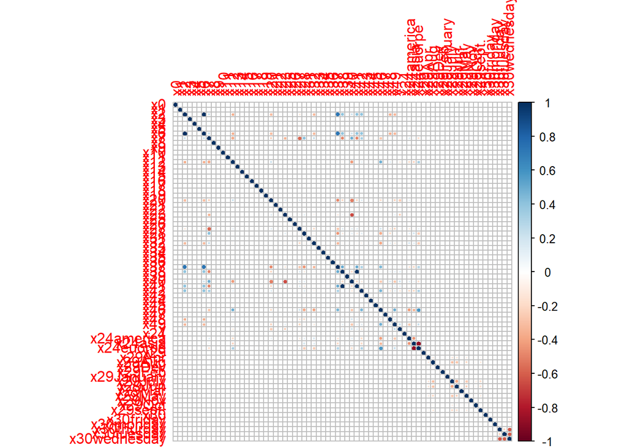

```r
cor3 <- cor(data_v3) #includes one hot encoded
corrplot(cor3, method = 'circle')
```

strong negative correlations between wedsnesday and tuesday, asia and europe 38 likely redundant with 41, 2 with 6 no strong correlation with any of the individual categorical variables and target y

```r
#additional graphs of categorical variable distributions
```

#### Model 0: Baseline MLR

including all variables

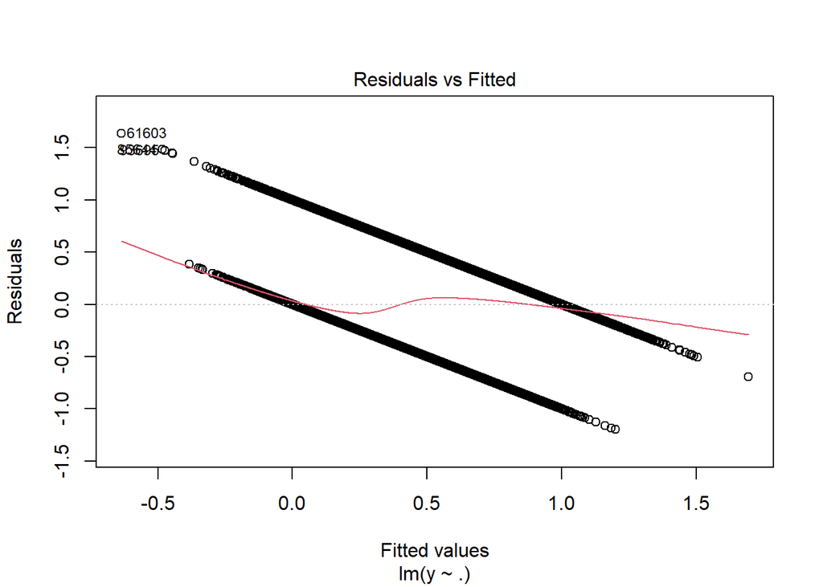

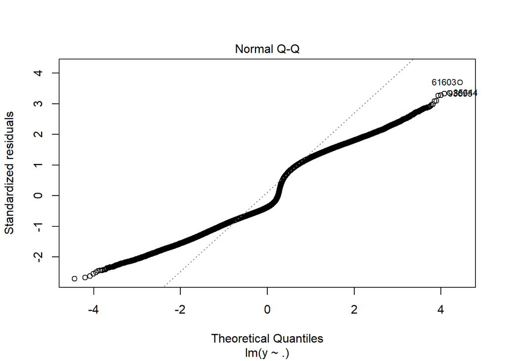

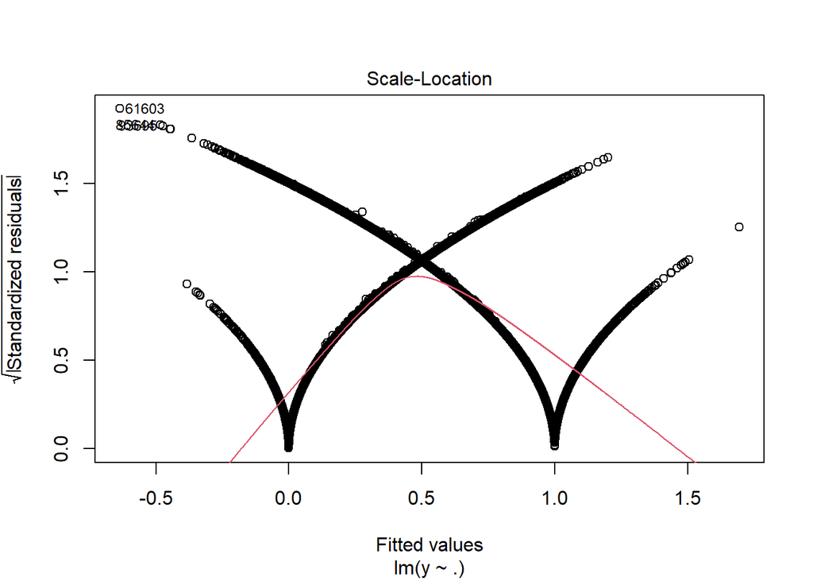

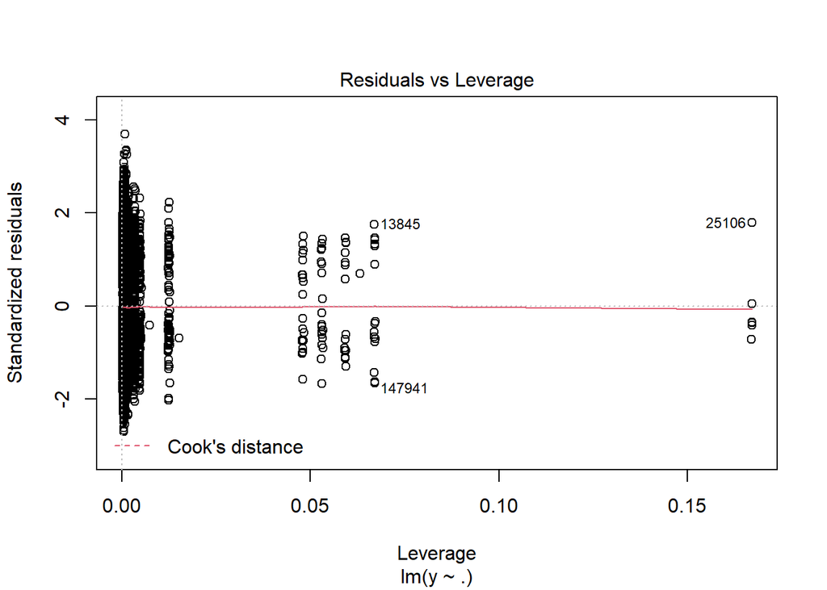

```r
set.seed(123412415)

train_index <- createDataPartition(data_v3$y, p = 0.7, list = FALSE)
train_v1 <- data_v3[train_index, ]
test_v1 <- data_v3[-train_index, ]


model0 <- lm(y ~. , train_v1)
summary(model0)
anova(model0)
plot(model0)
```

[output not shown]

```r
resultsv1 <- function(actual_values, predictions){
  ctable <- table(actual_values, predictions)
  cmat <- confusionMatrix(ctable)
  #print(cmat)
  #return(cmat)
  d_out <- (ctable[2, 1]*500 + ctable[1, 2] *10)
  s_output <- (paste('total cost of errors from model: $', format(d_out, big.mark = ',')))
  fn_chance <- ctable[2, 1]/(ctable[1, 1]+ctable[2, 1]) #%of negative predictions that are false negatives
  fp_chance <- ctable[1, 2]/(ctable[1, 2] + ctable[2, 2]) #%of positive predictions that are false positives
  return(list(cmat, s_output, d_out, fn_chance, fp_chance))
}
```

```r
#predictions
m0_preds <- predict(model0, newdata = test_v1)
test_pred <- ifelse(m0_preds > 0.5, 1, 0) #round results from model to zero or one
resultsv1(test_v1$y, test_pred)
```

```
## [[1]]
## Confusion Matrix and Statistics
##
##              predictions
## actual_values     0     1
##             0 23699  4817
##             1  9343  9685
##
##                Accuracy : 0.7022
##                  95% CI : (0.698, 0.7063)
##     No Information Rate : 0.695
##     P-Value [Acc > NIR] : 0.0003265
##
##                   Kappa : 0.3541
##
##  Mcnemar's Test P-Value : < 2.2e-16
##
##             Sensitivity : 0.7172
##             Specificity : 0.6678
##          Pos Pred Value : 0.8311
##          Neg Pred Value : 0.5090
##              Prevalence : 0.6950
##          Detection Rate : 0.4985
##    Detection Prevalence : 0.5998
##       Balanced Accuracy : 0.6925
##
##        'Positive' Class : 0
##
##
## [[2]]
## [1] "total cost of errors from model: $ 4,719,670"
##
## [[3]]
## [1] 4719670
##
## [[4]]
## [1] 0.2827613
##
## [[5]]
## [1] 0.3321611
```

Not too bad, 70% accuracy with linear regression, 28% chance of negatives being costly mistakes

### MLR with reduced variables

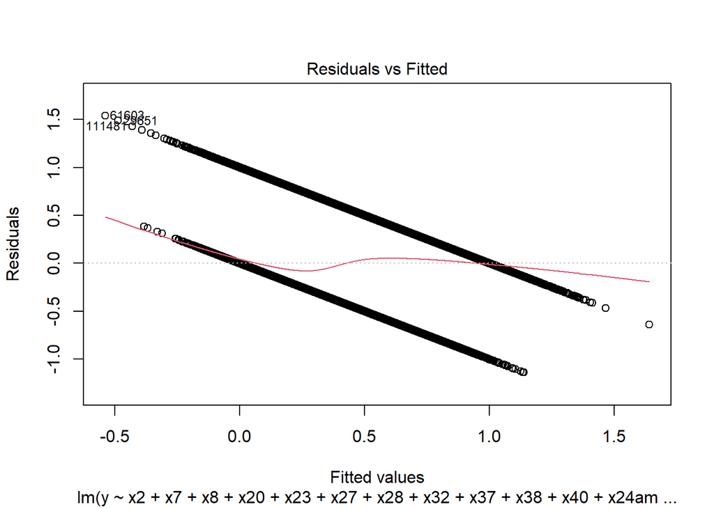

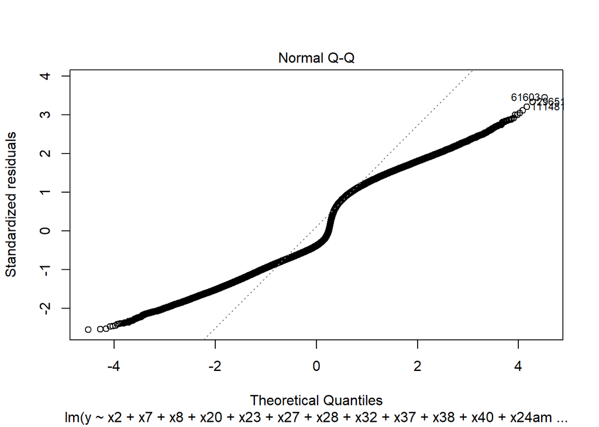

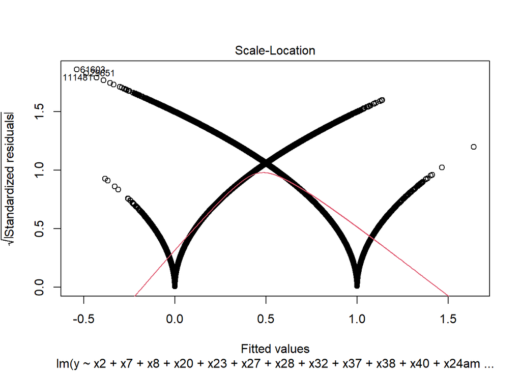

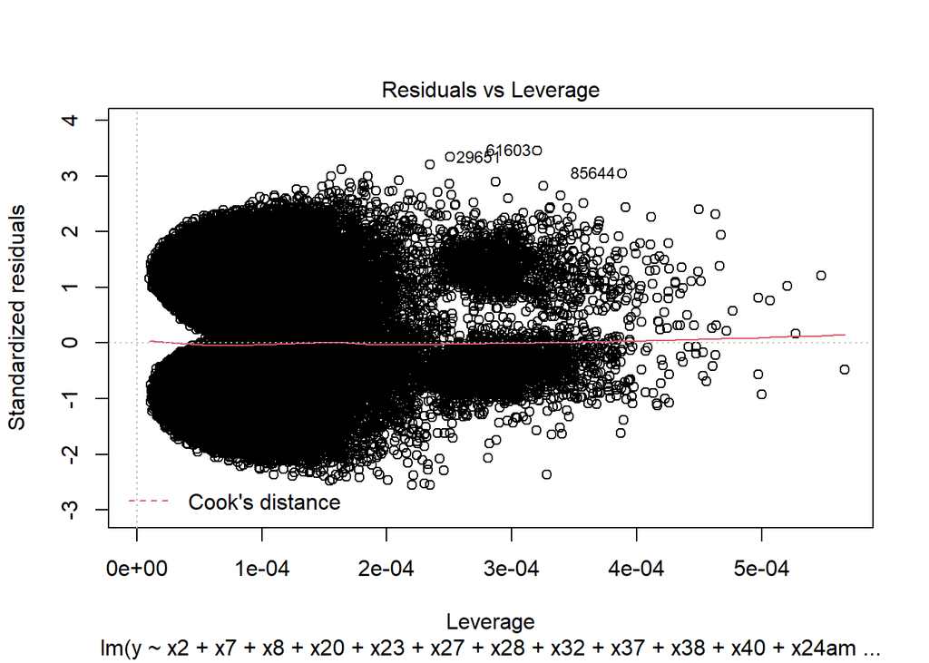

```r
model0.1 <- lm(y ~ x2 + x7 + x8 + x20 + x23 + x27 + x28 + x32 + x37 + x38 + x40 + x24america, data_v3)
summary(model0.1)
anova(model0.1)
plot(model0.1)
```

```r
m0.1_preds <- predict(model0.1, newdata = test_v1)
test_pred <- ifelse(m0.1_preds > 0.5, 1, 0) #round results from model to zero or one
m0_results <- resultsv1(test_v1$y, test_pred)
m0_results
```

[output not shown]

about the same performance with less variables

#### Model 1: Single Layer Neural Net

NN classification test 1

```r
start.time <- Sys.time()
set.seed(123412415)
#stuttgart neural network simulator test
#where size = units in hidden layer
inputs_v3 <- data.matrix(data_v3[, -data_v3$y]) #one hot encoded set
target_v3 <- data.matrix(data_v3$y)
#inputs_v3 <- data.matrix(data_v2[, -data_v2$y]) #categorical set
#target_v3 <- data.matrix(data_v2$y)
data_v4 <- splitForTrainingAndTest(inputs_v3, target_v3, ratio = 0.3)

model1 <- mlp(data_v4$inputsTrain, data_v4$targetsTrain, size = 5, learnFuncParams = c(0.1), maxit = 50, inputsTest = data_v4$inputsTest, targetsTest = data_v4$targetsTest)

end.time <- Sys.time()
time.taken <- end.time - start.time
print(paste('time ellapsed:', time.taken))
```

```
## [1] "time ellapsed: 1.78532018264135"
```

```r
summary(model1)
#model1
extractNetInfo(model1)
```

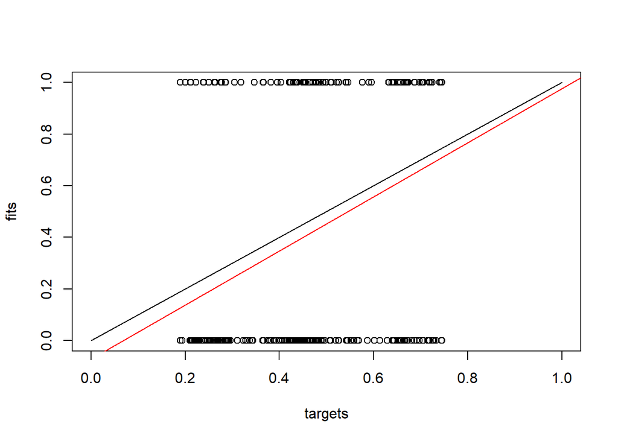

```r
plotRegressionError(model1$fittedTestValues, data_v4$targetsTest)
```

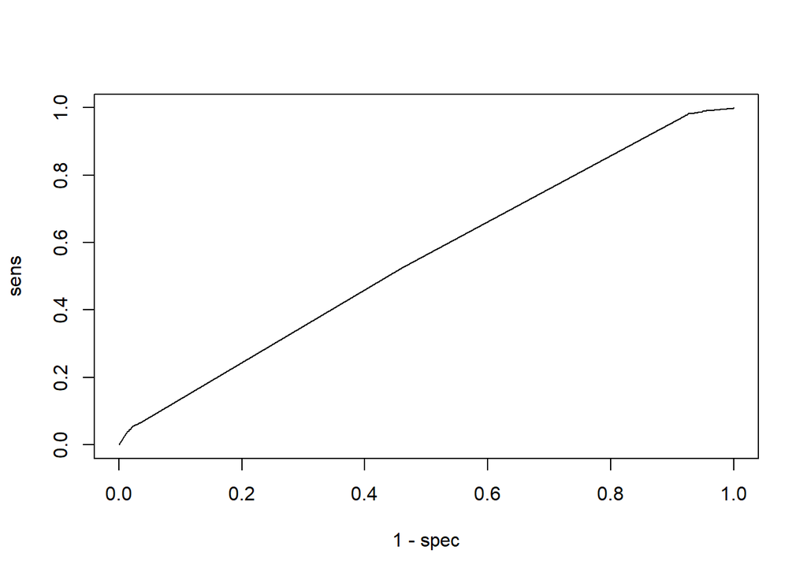

```r
plotROC(model1$fittedTestValues, data_v4$targetsTest)
```

note that model outputs predictions as a gradient between zero and one, need to round up/down to get binary data to compare against actual data false positive = -10$ false negative = -500$

problem, monetary metric is not generalizable across different test sizes, use ratio of false positve to false negative instead. functional output will be 1, confusion matrix, 2, table, 3 string output of cost estimation, 4, % negative predictions that were actually positive, 5, % positive predictions that were actually negative

```r
train_prob <- fitted.values(model1)
train_pred <- ifelse(train_prob > 0.5, 1, 0) #round results from model to zero or one
x <- resultsv1(data_v4$targetsTrain, train_pred)
x
```

```
## [[1]]
## Confusion Matrix and Statistics
##
##              predictions
## actual_values     0     1
##             0 64979  1430
##             1 42154  2373
##
##                Accuracy : 0.6071
##                  95% CI : (0.6042, 0.61)
##     No Information Rate : 0.9657
##     P-Value [Acc > NIR] : 1
##
##                   Kappa : 0.0374
##
##  Mcnemar's Test P-Value : <2e-16
##
##             Sensitivity : 0.60653
##             Specificity : 0.62398
##          Pos Pred Value : 0.97847
##          Neg Pred Value : 0.05329
##              Prevalence : 0.96572
##          Detection Rate : 0.58573
##    Detection Prevalence : 0.59862
##       Balanced Accuracy : 0.61525
##
##        'Positive' Class : 0
##
##
## [[2]]
## [1] "total cost of errors from model: $ 21,091,300"
##
## [[3]]
## [1] 21091300
##
## [[4]]
## [1] 0.3934735
##
## [[5]]
## [1] 0.3760189
```

```r
test_prob <- model1$fittedTestValues
test_pred <- ifelse(test_prob > 0.5, 1, 0)
m1_results <- resultsv1(data_v4$targetsTest, test_pred)
show(m1_results)
```

```
## [[1]]
## Confusion Matrix and Statistics
##
##              predictions
## actual_values     0     1
##             0 27841   646
##             1 17998  1059
##
##                Accuracy : 0.6079
##                  95% CI : (0.6035, 0.6123)
##     No Information Rate : 0.9641
##     P-Value [Acc > NIR] : 1
##
##                   Kappa : 0.0387
##
##  Mcnemar's Test P-Value : <2e-16
##
##             Sensitivity : 0.60736
##             Specificity : 0.62111
##          Pos Pred Value : 0.97732
##          Neg Pred Value : 0.05557
##              Prevalence : 0.96414
##          Detection Rate : 0.58558
##    Detection Prevalence : 0.59917
##       Balanced Accuracy : 0.61424
##
##        'Positive' Class : 0
##
##
## [[2]]
## [1] "total cost of errors from model: $ 9,005,460"
##
## [[3]]
## [1] 9005460
##
## [[4]]
## [1] 0.3926351
##
## [[5]]
## [1] 0.3788856
```

so iteration one of the model doesn’t do too well in either test or training sets, 60% accuracy isn’t great encoded categorical variables has about 1% less accuracy

#### Model 2: NN BackPropMomentum

NN classification test 2 functions available in the RSNNS package view with - getSnnsRFunctionTable()

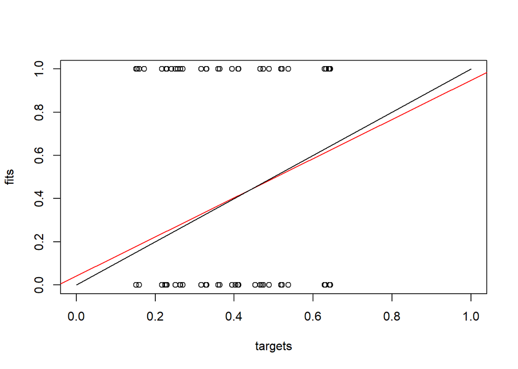

```r
start.time <- Sys.time()
#increasing layer size - no difference
#increase gradient descent step size - not much difference
#change learning function to backpropMomentum #slightly better, up to 70%
inputs_v3 <- data.matrix(data_v3[, -data_v3$y]) #one hot encoded set
target_v3 <- data.matrix(data_v3$y)
#inputs_v3 <- data.matrix(data_v2[, -data_v2$y])
#target_v3 <- data.matrix(data_v2$y)
data_v4 <- splitForTrainingAndTest(inputs_v3, target_v3, ratio = 0.3)

model2 <- mlp(data_v4$inputsTrain, data_v4$targetsTrain, size = 5, learnFunc = 'BackpropMomentum', learnFuncParams = c(0.1, 0.5, 0.1, 0.1), maxit = 50, inputsTest = data_v4$inputsTest, targetsTest = data_v4$targetsTest)
#for standard back propagation, parameters are stepsize of gradient descent
#for backprop momentum, parameters are stepsize, momentum, flatspot elimination, and dmax???

#parameter explainations here - http://www.ra.cs.uni-tuebingen.de/SNNS/UserManual/node52.html#SECTION00540000000000000000

summary(model2)
plotRegressionError(model2$fittedTestValues, data_v4$targetsTest)
```

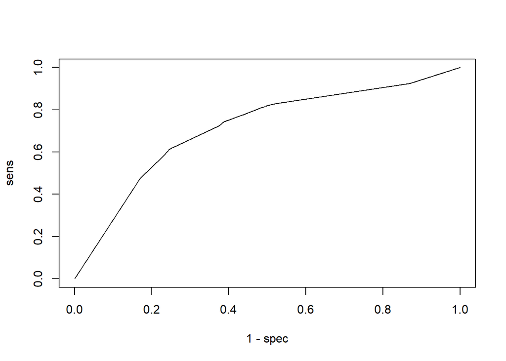

```r
plotROC(model2$fittedTestValues, data_v4$targetsTest)
```

```r
end.time <- Sys.time()
time.taken <- end.time - start.time
print(paste('time ellapsed:', time.taken))
```

```r
train_prob <- fitted.values(model2)
train_pred <- ifelse(train_prob > 0.5, 1, 0) #round results from model to zero or one
resultsv1(data_v4$targetsTrain, train_pred)
```

```
## [[1]]
## Confusion Matrix and Statistics
##
##              predictions
## actual_values     0     1
##             0 49891 16518
##             1 17481 27046
##
##                Accuracy : 0.6935
##                  95% CI : (0.6908, 0.6962)
##     No Information Rate : 0.6073
##     P-Value [Acc > NIR] : < 2.2e-16
##
##                   Kappa : 0.36
##
##  Mcnemar's Test P-Value : 1.816e-07
##
##             Sensitivity : 0.7405
##             Specificity : 0.6208
##          Pos Pred Value : 0.7513
##          Neg Pred Value : 0.6074
##              Prevalence : 0.6073
##          Detection Rate : 0.4497
##    Detection Prevalence : 0.5986
##       Balanced Accuracy : 0.6807
##
##        'Positive' Class : 0
##
##
## [[2]]
## [1] "total cost of errors from model: $ 8,905,680"
##
## [[3]]
## [1] 8905680
##
## [[4]]
## [1] 0.2594698
##
## [[5]]
## [1] 0.3791663
```

```r
test_prob <- model2$fittedTestValues
test_pred <- ifelse(test_prob > 0.5, 1, 0)
m1.2_results <- resultsv1(data_v4$targetsTest, test_pred)
show(m1.2_results)
```

```
## [[1]]
## Confusion Matrix and Statistics
##
##              predictions
## actual_values     0     1
##             0 21501  6986
##             1  7387 11670
##
##                Accuracy : 0.6977
##                  95% CI : (0.6935, 0.7018)
##     No Information Rate : 0.6076
##     P-Value [Acc > NIR] : < 2.2e-16
##
##                   Kappa : 0.3684
##
##  Mcnemar's Test P-Value : 0.0008485
##
##             Sensitivity : 0.7443
##             Specificity : 0.6255
##          Pos Pred Value : 0.7548
##          Neg Pred Value : 0.6124
##              Prevalence : 0.6076
##          Detection Rate : 0.4522
##    Detection Prevalence : 0.5992
##       Balanced Accuracy : 0.6849
##
##        'Positive' Class : 0
##
##
## [[2]]
## [1] "total cost of errors from model: $ 3,763,360"
##
## [[3]]
## [1] 3763360
##
## [[4]]
## [1] 0.2557117
##
## [[5]]
## [1] 0.374464
```

switching the nn to a momentum based backpropagation function brings general accuracy up to 70%, but also greatly reduces the number of false negatives, decreasing costs

let’s iterate on that decision boundary

```r
#decision between 0.3 and 0.6 are necessary to avoid predicting all 1 or 0, determined by looking at range of values for predictions
#aimed at the testing split
boundary_seeker <- function(test_probability, actual_test_data){
  blist <- seq(min(test_probability), max(test_probability), 0.05)
  fn_holder <- list()
  fp_holder <- list()
  a_holder <- list()
  d_holder <- list()
  for(i in 1:length(blist)){
    test_pred <- ifelse(test_probability > blist[i], 1, 0)
    temp1 <- resultsv1(actual_test_data, test_pred)
    fn_holder[i] <- temp1[[1]]$table[2, 1]
    fp_holder[i] <- temp1[[1]]$table[1, 2]
    a_holder[i] <- temp1[[1]]$overall[[1]] #stores the accuracy rating from the output
    d_holder[i] <- temp1[[3]] #stores dollar amount
    }
  #and visualize
  #values are scaled for the dataframe melt in order to get the cost in millions in the same neighborhood as percent accuracy
  #dataframe from flattened list of lists, indexing the results from function return got a bit messy
  btable <- data.table('boundary' = blist,
                       'false negatives' = scale(unlist(fn_holder)),
                       'false positive' = scale(unlist(fp_holder)),
                       'accuracy' = scale(unlist(a_holder)),
                       'cost' = scale(unlist(d_holder))) #don't need cost for visualization, as cost and false negatives are linear?
  btable2 <- melt(btable, id = 1) #condenses the datatable 2x col with labels for ggplot's categorical coloring
  #head(btable2)
  decision <- ggplot(btable2) +
    geom_line(aes(x = boundary, y = value, col = variable))+
    ggtitle('Model results based on decision boundary')
  show(decision)
  }
```

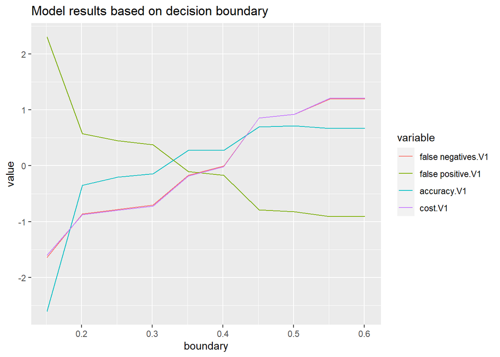

```r
boundary_seeker(test_prob, data_v4$targetsTest)
```

We can see that adjusting the classification boundary of the weighted output from the NN can greatly reduce cost at the expense of accuracy. The output from this function is scaled at zero in order to fit the scales of the estimated cost and accuracy on the same graph in a readable fashion. As a result the maximum values do not represent maximum accuracy or cost, just the upper range of the recorded accuracy and cost We can minimize cost at the expense of extremely high false positive rate and low accuracy; always predicting a positive is however not usually a sound strategy. the highest accuracy is comes from setting the boundary around greater than 0.5, but also has high rate of false negatives. We can see that the optimal trade-off between cost and accuracy is somewhere in the middle holding all other parameters of the model constant.

Let’s adjust the decision boundary for predictions being classified as zero or oen

```r
train_prob <- fitted.values(model2)
train_pred <- ifelse(train_prob > 0.32, 1, 0) #round results from model to zero or one
resultsv1(data_v4$targetsTrain, train_pred)
```

```
## [[1]]
## Confusion Matrix and Statistics
##
##              predictions
## actual_values     0     1
##             0 37494 28915
##             1  9849 34678
##
##                Accuracy : 0.6506
##                  95% CI : (0.6478, 0.6534)
##     No Information Rate : 0.5732
##     P-Value [Acc > NIR] : < 2.2e-16
##
##                   Kappa : 0.3208
##
##  Mcnemar's Test P-Value : < 2.2e-16
##
##             Sensitivity : 0.7920
##             Specificity : 0.5453
##          Pos Pred Value : 0.5646
##          Neg Pred Value : 0.7788
##              Prevalence : 0.4268
##          Detection Rate : 0.3380
##    Detection Prevalence : 0.5986
##       Balanced Accuracy : 0.6686
##
##        'Positive' Class : 0
##
##
## [[2]]
## [1] "total cost of errors from model: $ 5,213,650"
##
## [[3]]
## [1] 5213650
##
## [[4]]
## [1] 0.208035
##
## [[5]]
## [1] 0.4546884
```

```r
test_prob <- model2$fittedTestValues
test_pred <- ifelse(test_prob > 0.32, 1, 0)
resultsv1(data_v4$targetsTest, test_pred)
```

```
## [[1]]
## Confusion Matrix and Statistics
##
##              predictions
## actual_values     0     1
##             0 16118 12369
##             1  4302 14755
##
##                Accuracy : 0.6494
##                  95% CI : (0.645, 0.6536)
##     No Information Rate : 0.5705
##     P-Value [Acc > NIR] : < 2.2e-16
##
##                   Kappa : 0.3178
##
##  Mcnemar's Test P-Value : < 2.2e-16
##
##             Sensitivity : 0.7893
##             Specificity : 0.5440
##          Pos Pred Value : 0.5658
##          Neg Pred Value : 0.7743
##              Prevalence : 0.4295
##          Detection Rate : 0.3390
##    Detection Prevalence : 0.5992
##       Balanced Accuracy : 0.6667
##
##        'Positive' Class : 0
##
##
## [[2]]
## [1] "total cost of errors from model: $ 2,274,690"
##
## [[3]]
## [1] 2274690
##
## [[4]]
## [1] 0.2106758
##
## [[5]]
## [1] 0.4560168
```

```r
m2_results <- resultsv1(data_v4$targetsTest, test_pred)
```

#### Model 3: NN w/BackpropMomentum and TANH

NN classification test 3

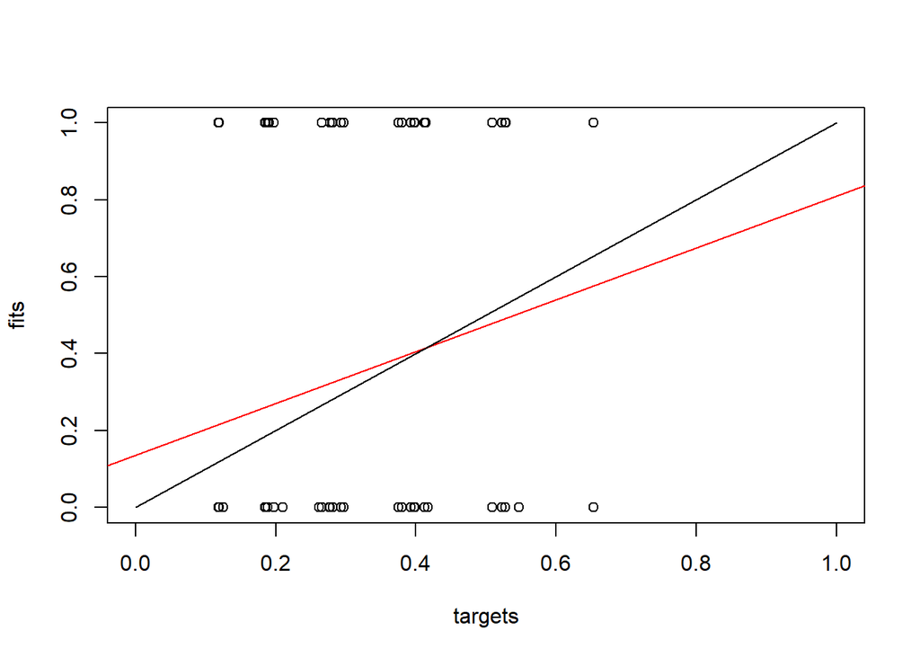

```r
#with tanh as activation function
inputs_v3 <- data.matrix(data_v3[, -data_v3$y])
target_v3 <- data.matrix(data_v3$y)
data_v4 <- splitForTrainingAndTest(inputs_v3, target_v3, ratio = 0.3)

model3 <- mlp(data_v4$inputsTrain, data_v4$targetsTrain, size = 5,
              initFunc = 'Randomize_Weights', initFuncParams = c(-.1, 0.1),
              learnFunc = 'BackpropMomentum', learnFuncParams = c(0.1, 0.5, 0.1, 0.1),
              hiddenActFunc = 'Act_TanH' ,
              maxit = 50,
              inputsTest = data_v4$inputsTest,
              targetsTest = data_v4$targetsTest)

summary(model3)
plotRegressionError(model3$fittedTestValues, data_v4$targetsTest)
```

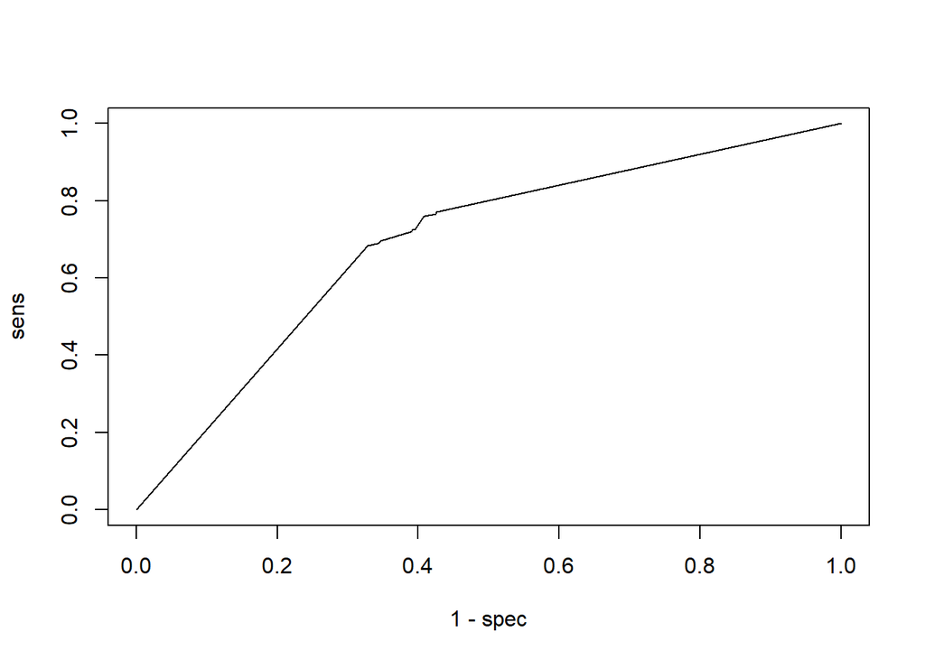

```r
plotROC(model3$fittedTestValues, data_v4$targetsTest)
```

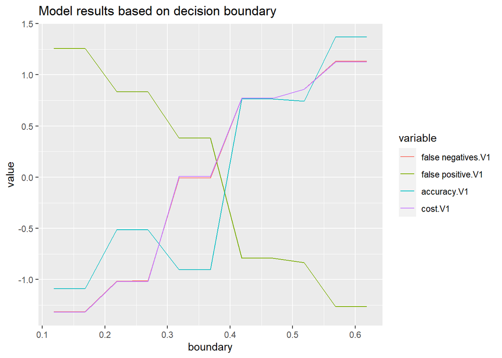

```r
boundary_seeker(model3$fittedTestValues, data_v4$targetsTest)
```

interesting shapes here, intersection at 0.32 or 0.42 might be the the ideal balance between cost and acurracy?

```r
# boundary_value = 0.17
# train_prob <- fitted.values(model2)
# train_pred <- ifelse(train_prob > boundary_value, 1, 0) #round results from model to zero or one
# resultsv1(append(data_v4$targetsTrain, c(1, 0)), append(train_pred, c(1, 0)))

test_pred <- ifelse(test_prob > .5, 1, 0)
resultsv1(append(data_v4$targetsTest, c(1, 0)), append(test_pred, c(1, 0)))
```

```
## [[1]]
## Confusion Matrix and Statistics
##
##              predictions
## actual_values     0     1
##             0 21502  6986
##             1  7387 11671
##
##                Accuracy : 0.6977
##                  95% CI : (0.6936, 0.7018)
##     No Information Rate : 0.6076
##     P-Value [Acc > NIR] : < 2.2e-16
##
##                   Kappa : 0.3685
##
##  Mcnemar's Test P-Value : 0.0008485
##
##             Sensitivity : 0.7443
##             Specificity : 0.6256
##          Pos Pred Value : 0.7548
##          Neg Pred Value : 0.6124
##              Prevalence : 0.6076
##          Detection Rate : 0.4522
##    Detection Prevalence : 0.5992
##       Balanced Accuracy : 0.6849
##
##        'Positive' Class : 0
##
##
## [[2]]
## [1] "total cost of errors from model: $ 3,763,360"
##
## [[3]]
## [1] 3763360
##
## [[4]]
## [1] 0.2557029
##
## [[5]]
## [1] 0.3744439
```

```r
test_prob <- model2$fittedTestValues
test_pred <- ifelse(test_prob > .32, 1, 0)
resultsv1(append(data_v4$targetsTest, c(1, 0)), append(test_pred, c(1, 0))) #adding singular instances of either class to validate mono class sorting results(it won't work normally if either entry into results v1 is all 1's or 0's)
```

```
## [[1]]
## Confusion Matrix and Statistics
##
##              predictions
## actual_values     0     1
##             0 16119 12369
##             1  4302 14756
##
##                Accuracy : 0.6494
##                  95% CI : (0.6451, 0.6537)
##     No Information Rate : 0.5705
##     P-Value [Acc > NIR] : < 2.2e-16
##
##                   Kappa : 0.3178
##
##  Mcnemar's Test P-Value : < 2.2e-16
##
##             Sensitivity : 0.7893
##             Specificity : 0.5440
##          Pos Pred Value : 0.5658
##          Neg Pred Value : 0.7743
##              Prevalence : 0.4295
##          Detection Rate : 0.3390
##    Detection Prevalence : 0.5992
##       Balanced Accuracy : 0.6667
##
##        'Positive' Class : 0
##
##
## [[2]]
## [1] "total cost of errors from model: $ 2,274,690"
##
## [[3]]
## [1] 2274690
##
## [[4]]
## [1] 0.2106655
##
## [[5]]
## [1] 0.456
```

```r
test_pred <- ifelse(test_prob > .42, 1, 0)
resultsv1(append(data_v4$targetsTest, c(1, 0)), append(test_pred, c(1, 0)))
```

```
## [[1]]
## Confusion Matrix and Statistics
##
##              predictions
## actual_values     0     1
##             0 21281  7207
##             1  7234 11824
##
##                Accuracy : 0.6963
##                  95% CI : (0.6921, 0.7004)
##     No Information Rate : 0.5997
##     P-Value [Acc > NIR] : <2e-16
##
##                   Kappa : 0.3675
##
##  Mcnemar's Test P-Value : 0.8287
##
##             Sensitivity : 0.7463
##             Specificity : 0.6213
##          Pos Pred Value : 0.7470
##          Neg Pred Value : 0.6204
##              Prevalence : 0.5997
##          Detection Rate : 0.4476
##    Detection Prevalence : 0.5992
##       Balanced Accuracy : 0.6838
##
##        'Positive' Class : 0
##
##
## [[2]]
## [1] "total cost of errors from model: $ 3,689,070"
##
## [[3]]
## [1] 3689070
##
## [[4]]
## [1] 0.253691
##
## [[5]]
## [1] 0.3786979
```

```r
m3_results <- resultsv1(append(data_v4$targetsTest, c(1, 0)), append(test_pred, c(1, 0)))
```